# Mesure de la biodiversité et de la structuration spatiale de l’activité économique par l’entropie

14 janvier 2018

# Motivation

## La question

Comment mesurer la structuration spatiale en espace discret?

Applications :

- mesure de la biodiversité ;
- mesure de la concentration spatiale et de la spécialisation en économie géographique.

## Les outils

L’entropie mesure :

- le désordre (physique statistique, 19<sup>ème</sup> siècle) ;
- l’incertitude (théorie de l’information, Shannon 1948) ;
- l’inégalité (Theil 1967).

## La présentation

Les méthodes utilisées :

- L’entropie classique ;
- Sa généralisation ;
- Les nombres effectifs.

Transfert des développement de la littérature sur la biodiversité à l’économie géographique.

# L’entropie

## Définir le désordre

A l’origine, Carnot (1824)

- Second principe de la thermodynamique.

Précisément :

- Transfert de chaleur, $\mathrm{d}Q$, à somme nulle (1<sup>er</sup> principe) ;
- Tiédissement : $\mathrm{d}Q/T$, à somme positive (2<sup>nd</sup> principe). Augmentation du désordre.

Remarque : l’entropie est définie par sa variation (étymologie: *transformation*).

## Boltzmann

Un gaz est un ensemble de particules, chacune ayant plusieurs états possibles.

L’entropie est proportionnelle au logarithme du nombre d’états possibles de l’ensemble des particules (1877, traduit par Sharp and Matschinsky 2015).

Lien avec le second principe.

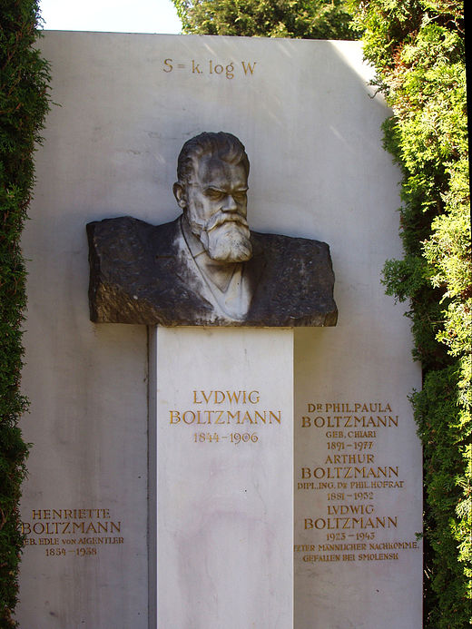

Tombe de Boltzmann

## Mesurer le désordre

Définition d’une chaîne de caractères :

- longueur $n$ ;
- alphabet probabilisé.

Exemple :

- 3 lettres, {a, b, c}, fréquences (1/2, 1/3, 1/6) ;
- Combien de chaînes de 60 caractères ?
- Le logarithme du nombre de chaînes est $n$ fois l’entropie : $61$.

L’entropie de Shannon mesure la complexité de la distribution de {a, b, c}, indépendamment de la longueur de la chaîne : 1.01

## Mesurer l’incertitude

Expérience à plusieurs résultats possibles.

- La probabilité d’obtenir $r_s$ est $p_s$.

Fonction d’information : $I(p_s)$, entre $I(0)=+\infty$ et $I(1)=0$.

- Définition : la rareté est $1/p_s$.
- Le logarithme de la rareté est la fonction d’information de Shannon.

L’information apportée par l’ensemble des individus est l’entropie de Shannon:
$$\sum_s{p_s \ln {\frac{1}{p_s}}}$$

## Entropie généralisée

Autres entropies : Rényi, Shorrocks… Tsallis (1988)

Paramétriques.

Logarithme déformé :

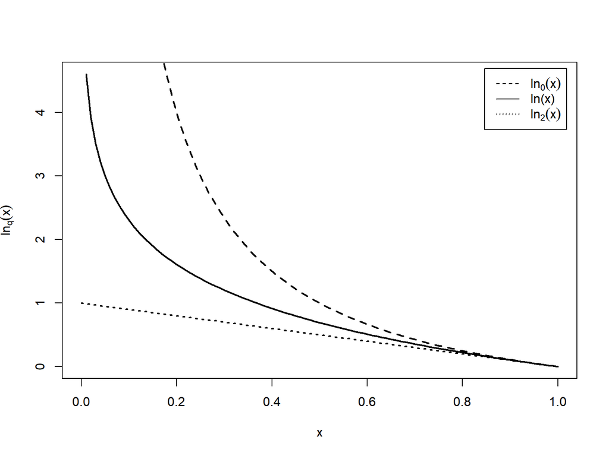

## Formalisation

L’entropie de Tsallis est la moyenne du logarithme (déformé, d’ordre $q$) de la rareté.

L’ordre $q$ donne une importance plus ou moins grande aux petites probabilités.

- Entropie d’ordre 0 : le nombre de catégories (-1) ;
- Entropie d’ordre 1 : Shannon ;
- Entropie d’ordre 2 : Simpson (1-Herfindahl).

## Nombres de Hill

Nombre de catégories équiprobables de même entropie que celle du système observé (Hill 1973).

Exponentielle de l’entropie.

Profil de diversité :

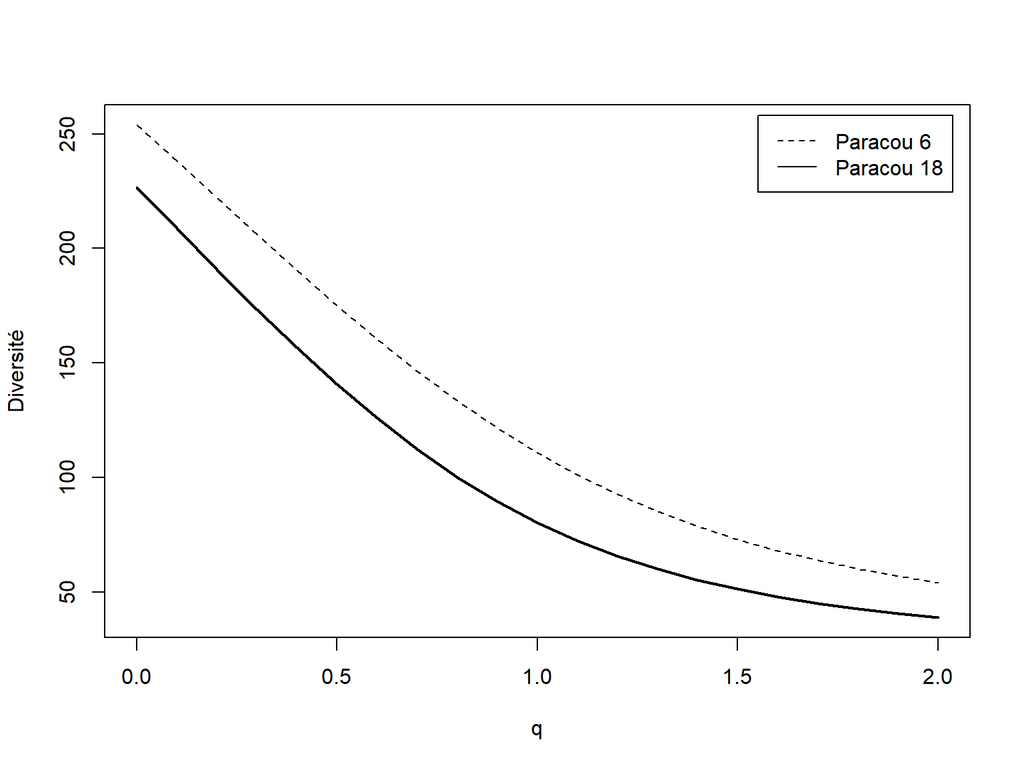

## Entropie relative

Ecart d’une distribution observée à une distribution attendue.

- Divergence de Kullback-Leibler ;
- Entropie relative de Theil.

Généralisation à l’ordre $q$ (Marcon et al. 2014).

Si la distribution attendue est la moyenne des distributions (assemblage) alors différence entre l’entropie de l’assemblage et celle de chaque système.

Transformation en nombres de Hill détaillée plus tard.

# Applications

## Questions similaires

Biodiversité :

- Nombres d’arbres par espèces dans un habitat forestier : biodiversité.
- Nombres d’arbres par habitat pour une espèce : ubiquité.

Economie :

- Nombre d’employés par secteur industriel dans un pays : diversité = contraire de la spécialisation.
- Nombre d’employés par pays pour un secteur : ubiquité = contraire de la concentration spatiale.

|  | AT | BE |
| --- | --- | --- |
| C10 | 71924 | 85083 |
| C11 | 9319 | 9814 |
| C13 | 8665 | 17329 |
| C14 | 6212 | 3495 |
| C16 | 32762 | 11271 |
| C17 | 17078 | 11044 |

## Spécialisation absolue

Transformation simple :

(Maximum possible - Valeur) / (Maximum possible - 1)

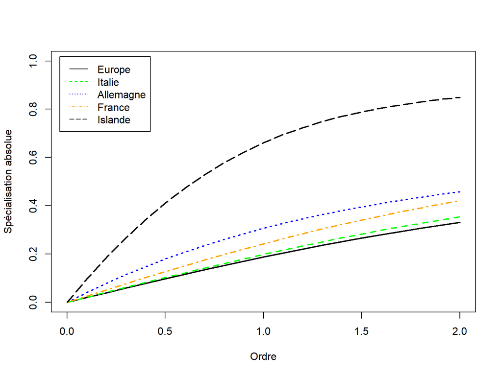

## Décomposition de l’entropie

Exemple : entropie des pays (diversité des secteurs)

- Entropie de l’Europe = moyenne des (entropies absolues + entropies relatives des pays).

Nombres de Hill :

- Diversité de l’Europe = Diversité moyenne des pays x nombre de pays effectifs.

Classique en écologie : diversités $\gamma$, $\alpha$ et $\beta$.

## Exemple

Diversité des secteurs industriels en Europe :

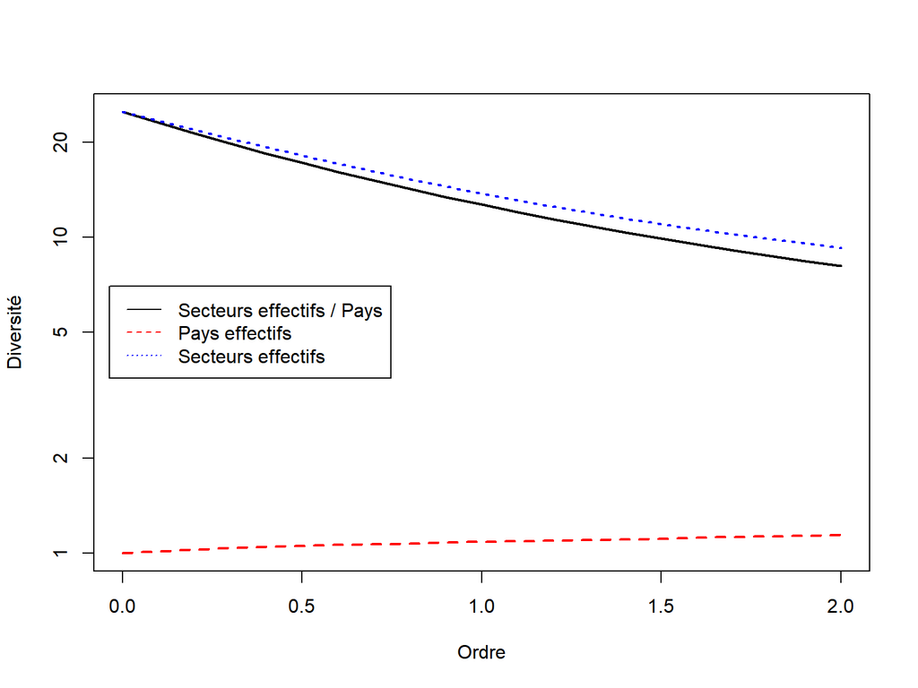

## Décomposition de la diversité jointe

Diversité de l’ensemble des effectifs : nombres d’employés par secteur et par pays.

- Nombre effectif d’unités.

Décomposition de l’entropie et de la diversité similaire, un élément supplémentaire: la redondance (Gregorius 2010).

Diversité jointe = Nombre effectif de secteurs par pays x nombre de pays effectifs x *redondance des pays*.

## Diversité jointe

Concentration spatiale de l’industrie européenne :

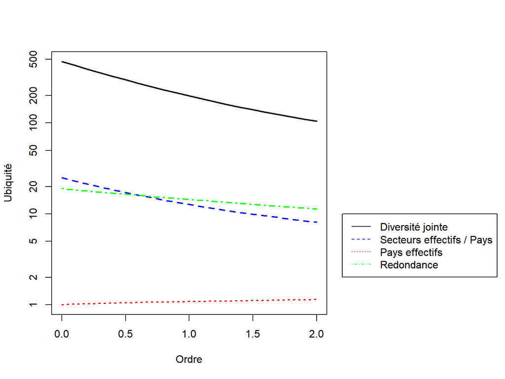

# Conclusion

## Concepts identiques, expression contraire

Diversité $\leftrightarrow$ Spécialisation.

Ubiquité $\leftrightarrow$ Concentration.

Raison : mise en avant de l’aspect positif.

## Absolu et relatif

Approches complémentaires dans la littérature économique.

Unification par l’entropie :

- liens étroits : significativité de l’une $\iff$ significativité de l’autre ;
- information très différente.

## Interfertilisation

De la physique à l’écologie : entropie de Tsallis.

De la théorie de l’information à l’écologie : divergence de Kullback and Leibler (1951).

De la théorie de l’information à l’économie : entropie relative de Theil.

En écologie : nombres effectifs.

En écologie théorique : redondance.

## Références

Gregorius, Hans-Rolf. 2010. “Linking Diversity and Differentiation.” *Diversity* 2 (3): 370–94. doi:10.3390/d2030370.

Hill, M. O. 1973. “Diversity and Evenness: A Unifying Notation and Its Consequences.” *Ecology* 54 (2): 427–32. doi:10.2307/1934352.

Kullback, S., and R. A. Leibler. 1951. “On Information and Sufficiency.” *The Annals of Mathematical Statistics* 22 (1): 79–86.

Marcon, Eric, Ivan Scotti, Bruno Hérault, Vivien Rossi, and Gabriel Lang. 2014. “Generalization of the Partitioning of Shannon Diversity.” *Plos One* 9 (3): e90289. doi:10.1371/journal.pone.0090289.

Shannon, Claude E. 1948. “A Mathematical Theory of Communication.” *The Bell System Technical Journal* 27: 379–423, 623–56.

Sharp, Kim, and Franz Matschinsky. 2015. “Translation of Ludwig Boltzmann’s paper ‘on the relationship between the second fundamental theorem of the mechanical theory of heat and probability calculations regarding the conditions for thermal equilibrium’.” *Entropy* 17 (4): 1971–2009. doi:10.3390/e17041971.

Theil, H. 1967. *Economics and Information Theory*. Chicago: Rand McNally & Company.

Tsallis, Constantino. 1988. “Possible generalization of Boltzmann-Gibbs statistics.” *Journal of Statistical Physics* 52 (1): 479–87. doi:10.1007/BF01016429.